# inovick_final_hw_code_04

# Install and load packages:

```r
#Load necessary packages
library(curl)
```

```r
library(ggplot2)
library(manipulate)
install.packages("gridExtra")
```

```
## Error in contrib.url(repos, "source"): trying to use CRAN without setting a mirror
```

```r
library(gridExtra)
install.packages("lmodel2")
```

```
## Error in contrib.url(repos, "source"): trying to use CRAN without setting a mirror
```

```r
library(lmodel2)
library(tidyr)
```

#Load data, fitting a regression model to predict longevity

```r
#Load the data using curl command
f <- curl("https://raw.githubusercontent.com/fuzzyatelin/fuzzyatelin.github.io/master/AN588_Fall21/KamilarAndCooperData.csv")
d <- read.csv(f, header = TRUE, sep = ",", stringsAsFactors = FALSE)
head(d)
```

```
##               Scientific_Name          Family          Genus      Species
## 1 Allenopithecus_nigroviridis Cercopithecidae Allenopithecus nigroviridis
## 2         Allocebus_trichotis Cercopithecidae      Allocebus    trichotis
## 3           Alouatta_belzebul        Atelidae       Alouatta     belzebul
## 4             Alouatta_caraya        Atelidae       Alouatta       caraya
## 5            Alouatta_guariba        Atelidae       Alouatta      guariba
## 6           Alouatta_palliata        Atelidae       Alouatta     palliata
##   Brain_Size_Species_Mean Brain_Size_Female_Mean   Brain_size_Ref
## 1                   58.02                  53.70 Isler et al 2008
## 2                      NA                     NA
## 3                   52.84                  51.19 Isler et al 2008
## 4                   52.63                  47.80 Isler et al 2008
## 5                   51.70                  49.08 Isler et al 2008
## 6                   49.88                  48.04 Isler et al 2008
##   Body_mass_male_mean Body_mass_female_mean Mass_Dimorphism
```

[output cut: 62 more lines]

```r
m <- lm(MaxLongevity_m ~ Brain_Size_Species_Mean, data = d)
m
```

```
##
## Call:
## lm(formula = MaxLongevity_m ~ Brain_Size_Species_Mean, data = d)
##
## Coefficients:
##             (Intercept)  Brain_Size_Species_Mean
##                 248.952                    1.218
```

```r
names(m)
```

```
##  [1] "coefficients"  "residuals"     "effects"       "rank"
##  [5] "fitted.values" "assign"        "qr"            "df.residual"
##  [9] "na.action"     "xlevels"       "call"          "terms"
## [13] "model"
```

```r
m$coefficients
```

```
##             (Intercept) Brain_Size_Species_Mean
##               248.95227                 1.21799
```

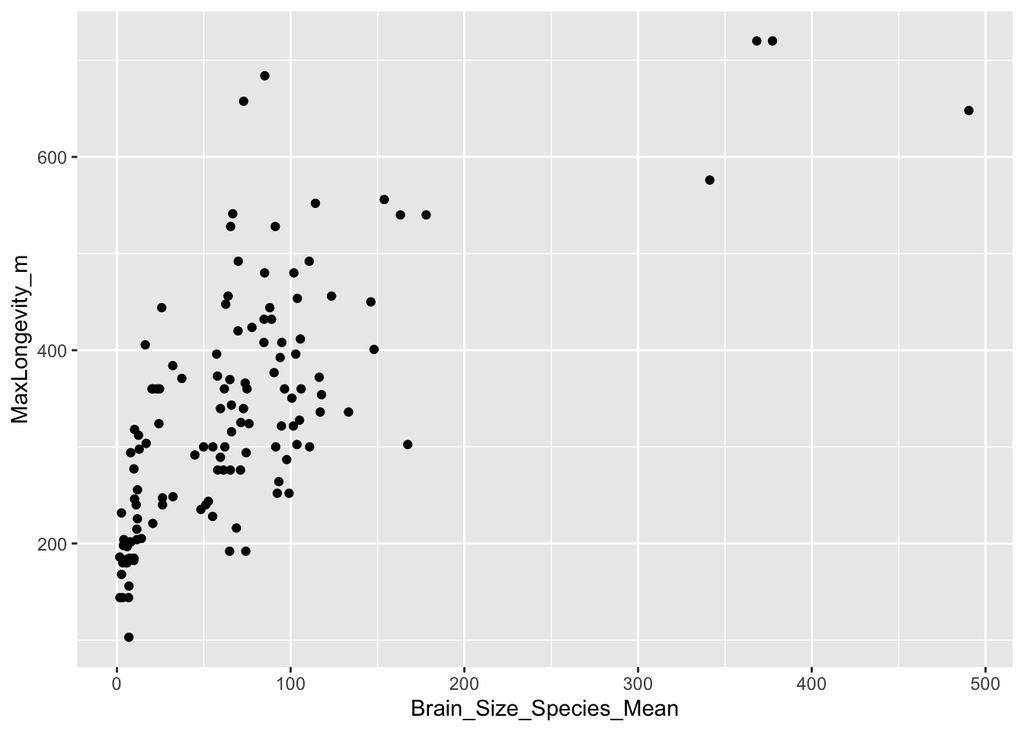

```r
lblm <- ggplot(data = d, aes(x = Brain_Size_Species_Mean, y = MaxLongevity_m))
lblm<- lblm + geom_point()
lbllm<- lblm + geom_smooth(method = "lm", formula = y ~ x) + xlab("Mean Species Brain Size (g)") + ylab("Max Species Longevity (months)") + theme_classic()
lblm
```

```r
loglbl<- lm(log(MaxLongevity_m) ~ log(Brain_Size_Species_Mean), data = d)
loglbl
```

```
##
## Call:
## lm(formula = log(MaxLongevity_m) ~ log(Brain_Size_Species_Mean),
##     data = d)
##
## Coefficients:
##                  (Intercept)  log(Brain_Size_Species_Mean)
##                       4.8790                        0.2341
```

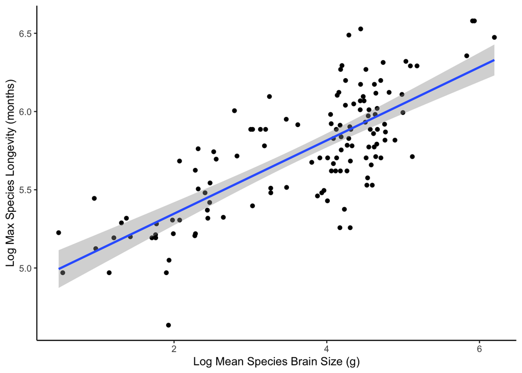

```r
loglblm <- ggplot(data = d, aes(x = log(Brain_Size_Species_Mean), y = log(MaxLongevity_m)))
loglblm<- loglblm + geom_point()
loglblm<- loglblm + geom_smooth(method = "lm", formula = y ~ x) + xlab("Log Mean Species Brain Size (g)") + ylab("Log Max Species Longevity (months)") + theme_classic()
loglblm
```

#Identify and interpret the point estimate of the slope (β1), as well as the outcome of the test associated with the hypotheses H0: β1 = 0; HA: β1 ≠ 0. Also, find a 90 percent CI for the slope (β1) parameter.

```r
summary(lbModel)
```

[output not shown]

```
## Error in summary(lbModel): object 'lbModel' not found
```

```r
ci <- confint(m, level = 0.90)
ci
```

```
##                                5 %      95 %
## (Intercept)             230.540738 267.36379
## Brain_Size_Species_Mean   1.035571   1.40041
```

```r
summary(loglbl)
```

```
##
## Call:
## lm(formula = log(MaxLongevity_m) ~ log(Brain_Size_Species_Mean),
##     data = d)
##
## Residuals:
##     Min      1Q  Median      3Q     Max
## -0.6955 -0.1750 -0.0097  0.1788  0.6084
##
## Coefficients:
##                              Estimate Std. Error t value Pr(>|t|)
## (Intercept)                   4.87895    0.06907   70.63   <2e-16 ***
## log(Brain_Size_Species_Mean)  0.23415    0.01781   13.15   <2e-16 ***
## ---
## Signif. codes:  0 '***' 0.001 '**' 0.01 '*' 0.05 '.' 0.1 ' ' 1
##
## Residual standard error: 0.2485 on 126 degrees of freedom
##   (85 observations deleted due to missingness)
## Multiple R-squared:  0.5784, Adjusted R-squared:  0.5751
## F-statistic: 172.9 on 1 and 126 DF,  p-value: < 2.2e-16
```

```r
ci <- confint(loglbl, level = 0.90)
ci
```

```
##                                    5 %      95 %
## (Intercept)                  4.7644934 4.9934084
## log(Brain_Size_Species_Mean) 0.2046396 0.2636595
```

```r
#Log transformed data is a better graph because it cuts out extra and fits it nicely
```

```r
#Made the variables into a dataframe first
df <- data.frame(x = d$MaxLongevity_m, y = d$Brain_Size_Species_Mean)


lm_eqn <- function(df){
    m <- lm(y ~ x, df);
    eq <- substitute(italic(y) == a + b %.% italic(x)*","~~italic(r)^2~"="~r2,
         list(a = format(unname(coef(m)[1]), digits = 2),
              b = format(unname(coef(m)[2]), digits = 2),
             r2 = format(summary(m)$r.squared, digits = 3)))
    as.character(as.expression(eq));
}
p1 <- g + geom_text(x = 200, y = 400, label = lm_eqn(df), parse = TRUE)
```

```
## Error in eval(expr, envir, enclos): object 'g' not found
```

```r
p1
```

[output not shown]

```r
h_hat <- predict(m, newdata = data.frame(Brain_Size_Species_Mean = d$Brain_Size_Species_Mean))
df <- data.frame(cbind(d$Brain_Size_Species_Mean, d$MaxLongevity_m, h_hat))
names(df) <- c("Mean Species Brain Size", "Max Longevity", "yhat")
head(df)
```

```
##   Mean Species Brain Size Max Longevity     yhat
## 1                   58.02         276.0 319.6201
## 2                      NA            NA       NA
## 3                   52.84            NA 313.3109
## 4                   52.63         243.6 313.0551
## 5                   51.70            NA 311.9224
## 6                   49.88         300.0 309.7056
```

```r
ci <- predict(m, newdata = data.frame(Brain_Size_Species_Mean = d$Brain_Size_Species_Mean),interval = "confidence",
    level = 0.95)
ci
```

```
##          fit      lwr      upr
## 1   319.6201 303.5156 335.7245
## 2         NA       NA       NA
## 3   313.3109 296.9899 329.6319
## 4   313.0551 296.7238 329.3864
## 5   311.9224 295.5437 328.3011
## 6   309.7056 293.2275 326.1838
## 7   311.2281 294.8192 327.6370
## 8   316.2097 299.9976 332.4218
## 9   274.1281 254.9708 293.2854
## 10        NA       NA       NA
## 11  268.8055 249.1014 288.5096
## 12        NA       NA       NA
## 13        NA       NA       NA
## 14  269.4754 249.8419 289.1090
```

[output cut: 199 more lines]

```r
df <- cbind(df, ci)
names(df) <- c("MeanSpeciesBrainSize", "MaxLongevity", "yhat", "CIfit", "CIlwr", "CIupr")
head(df)
```

```
##   MeanSpeciesBrainSize MaxLongevity     yhat    CIfit    CIlwr    CIupr
## 1                58.02        276.0 319.6201 319.6201 303.5156 335.7245
## 2                   NA           NA       NA       NA       NA       NA
## 3                52.84           NA 313.3109 313.3109 296.9899 329.6319
## 4                52.63        243.6 313.0551 313.0551 296.7238 329.3864
## 5                51.70           NA 311.9224 311.9224 295.5437 328.3011
## 6                49.88        300.0 309.7056 309.7056 293.2275 326.1838
```

```r
df
```

```
##     MeanSpeciesBrainSize MaxLongevity     yhat    CIfit    CIlwr    CIupr
## 1                  58.02       276.00 319.6201 319.6201 303.5156 335.7245
## 2                     NA           NA       NA       NA       NA       NA
## 3                  52.84           NA 313.3109 313.3109 296.9899 329.6319
## 4                  52.63       243.60 313.0551 313.0551 296.7238 329.3864
## 5                  51.70           NA 311.9224 311.9224 295.5437 328.3011
## 6                  49.88       300.00 309.7056 309.7056 293.2275 326.1838
## 7                  51.13       240.00 311.2281 311.2281 294.8192 327.6370
## 8                  55.22       300.00 316.2097 316.2097 299.9976 332.4218
## 9                  20.67       360.00 274.1281 274.1281 254.9708 293.2854
## 10                    NA           NA       NA       NA       NA       NA
## 11                 16.30       405.60 268.8055 268.8055 249.1014 288.5096
## 12                    NA           NA       NA       NA       NA       NA
## 13                    NA           NA       NA       NA       NA       NA
## 14                 16.85       303.60 269.4754 269.4754 249.8419 289.1090
```

[output cut: 199 more lines]

## Figuring out the best slope– identifying the point estimate of the slope

```r
slope.test <- function(beta1) {
    g <- ggplot(data = d, aes(x = d$Brain_Size_Species_Mean, y = MaxLongevity_m))
    g <- g + geom_point()
    g <- g + geom_abline(intercept = 0, slope = beta1, size = 1, colour = "blue",
        alpha = 1/2)
    ols <- sum((y - beta1 * x)^2)
    g <- g + ggtitle(paste("Slope = ", beta1, "\nSum of Squared Deviations = ",
        round(ols, 3)))
    g
}
#Using manipulate. It just gives me a gray square again. Why??
manipulate(slope.test(beta1), beta1 = slider(-1, 1, initial = 0, step = 0.005))
```

```
## Error in manipulate(slope.test(beta1), beta1 = slider(-1, 1, initial = 0, : The manipulate package must be run from within RStudio
```

#Confidence interval

```r
ci <- confint(m, level = 0.90) # using the results of lm()
ci
```

```
##                                5 %      95 %
## (Intercept)             230.540738 267.36379
## Brain_Size_Species_Mean   1.035571   1.40041
```

```

## Peer Commentary - NN

- What you learned from running their Original Homework Code that helped improve your own code. My biggest takeaway from your code is the value in consulting external resources like StackExchange since you were able to figure out how to do things (e.g. adding legends) that I didn’t even know how to approach. I also appreciate the “stream of consciousness” that’s throughout your code since it makes it clear to the viewer why you chose to do certain things.
- What you did in your own code that might help to improve theirs. Our codes are pretty similar but I’d say the only difference is our methods of commenting. I personally find it easier to follow if the comments are separate from the code so when the file is knitted they aren’t intermingled with the code - however, if this isn’t your preference I think your code looks good!
- What challenges, if any, you both faced in your code that could not be helped by comparison. I think we’re both confused with the second half of challenge 2 and that can only be helped by consulting the modules and other online resources.
- Whether the annotation/commenting on your peer’s Original Homework Code is readable and interpretable to you, and if not then how it could be improved. For the most part I was able to follow the annotations and comments in your code, I like how you included code that wasn’t necessarily successful too since that shows the breadth of your attempts and the different methods that you considered for answering the various questions.

Overall, good job! This has been the hardest assignment for me and I think your code looks great.